# OIL-DATA-NOTEBOOK

```python
import pandas as pd
import numpy as np
import matplotlib.pyplot as plt
```

```python
file='POZOS_COMPILADO.csv'
wells=pd.read_csv(file,encoding='latin-1',low_memory=False)
```

```python
# with open('POZOS_COMPILADO.csv','r') as file1:
#    wells_compiled=file1.read()
```

```python
# with open('POZOS_COMPILADO.csv','r') as file1:
#    wells_compiled=file1.read()
#    print(len(wells_compiled))
```

```python
# with open('POZOS_COMPILADO.csv','r') as file1:
#    header=file1.readlines(100)
#    print(header)
```

```python
# with open('POZOS_COMPILADO.csv','r') as file1:
#    header=file1.read()
```

```python
#header.to_csv('header_df')
#wells_df=pd.read_csv('header')
# wells_obj=header.split(",")
```

```python
# wells_obj=np.array(wells_obj)
```

```python
# wells_obj.shape
```

```python
# wells_df=pd.DataFrame(wells_obj)
```

```python
wells.head(50)
```

|  | Fecha | Cuenca | Asignación_o_Contrato | Nombre_del_pozo | Petróleo_(Mbd) | Gas_asociado_(MMpcd) | Gas_no_asociado_(MMpcd) | Agua_(Mbd) | Condensado_(Mbd) |
| --- | --- | --- | --- | --- | --- | --- | --- | --- | --- |
| 0 | 01-06-1930 | TAMPICO-MISANTLA | NaN | POZA RICA-2 | 0.009015 | 0.004180 | 0.0 | 0.0 | 0.0 |
| 1 | 01-07-1930 | TAMPICO-MISANTLA | NaN | POZA RICA-2 | 0.020695 | 0.009594 | 0.0 | 0.0 | 0.0 |
| 2 | 01-08-1930 | TAMPICO-MISANTLA | NaN | POZA RICA-2 | 0.020695 | 0.009594 | 0.0 | 0.0 | 0.0 |
| 3 | 01-09-1930 | TAMPICO-MISANTLA | NaN | POZA RICA-2 | 0.020756 | 0.009622 | 0.0 | 0.0 | 0.0 |
| 4 | 01-10-1930 | TAMPICO-MISANTLA | NaN | POZA RICA-2 | 0.020695 | 0.009594 | 0.0 | 0.0 | 0.0 |
| 5 | 01-11-1930 | TAMPICO-MISANTLA | NaN | POZA RICA-2 | 0.020756 | 0.009622 | 0.0 | 0.0 | 0.0 |
| 6 | 01-12-1930 | TAMPICO-MISANTLA | NaN | POZA RICA-2 | 0.020695 | 0.009594 | 0.0 | 0.0 | 0.0 |
| 7 | 01-01-1931 | TAMPICO-MISANTLA | NaN | POZA RICA-2 | 0.020695 | 0.009594 | 0.0 | 0.0 | 0.0 |
| 8 | 01-02-1931 | TMPICO-MISANTLA | NaN | POZA RICA-2 | 0.020666 | 0.009580 | 0.0 | 0.0 | 0.0 |
| 9 | 01-03-1931 | TAMPICO-MISANTLA | NaN | POZA RICA-2 | 0.020695 | 0.009594 | 0.0 | 0.0 | 0.0 |
| 10 | 01-04-1931 | TAMPICO-MISANTLA | NaN | POZA RICA-2 | 0.020756 | 0.009622 | 0.0 | 0.0 | 0.0 |
| 11 | 01-05-1931 | TAMPICO-MISANTLA | NaN | POZA RICA-2 | 0.020695 | 0.009594 | 0.0 | 0.0 | 0.0 |
| 12 | 01-06-1931 | TAMPICO-MISANTLA | NaN | POZA RICA-2 | 0.020756 | 0.009622 | 0.0 | 0.0 | 0.0 |
| 13 | 01-07-1931 | TAMPICO-MISANTLA | NaN | POZA RICA-2 | 0.020695 | 0.009594 | 0.0 | 0.0 | 0.0 |
| 14 | 01-08-1931 | TAMPICO-MISANTLA | NaN | POZA RICA-2 | 0.032058 | 0.009594 | 0.0 | 0.0 | 0.0 |
| 15 | 01-09-1931 | TAMPICO-MISANTLA | NaN | POZA RICA-2 | 0.033965 | 0.005373 | 0.0 | 0.0 | 0.0 |
| 16 | 01-10-1931 | TAMPICO-MISANTLA | NaN | POZA RICA-2 | 0.045246 | 0.003800 | 0.0 | 0.0 | 0.0 |
| 17 | 01-11-1931 | TAMPICO-MISANTLA | NaN | POZA RICA-2 | 0.045287 | 0.003805 | 0.0 | 0.0 | 0.0 |
| 18 | 01-12-1931 | TAMPICO-MISANTLA | NaN | POZA RICA-2 | 0.032058 | 0.007901 | 0.0 | 0.0 | 0.0 |
| 19 | 01-01-1932 | TAMPICO-MISANTLA | NaN | POZA RICA-2 | 0.046463 | 0.021540 | 0.0 | 0.0 | 0.0 |
| 20 | 01-02-1932 | TAMPICO-MISANTLA | NaN | POZA RICA-2 | 0.016917 | 0.022411 | 0.0 | 0.0 | 0.0 |
| 21 | 01-03-1932 | TAMPICO-MISANTLA | NaN | POZA RICA-2 | 0.030840 | 0.021477 | 0.0 | 0.0 | 0.0 |
| 22 | 01-04-1932 | TAMPICO-MISANTLA | NaN | POZA RICA-2 | 0.041513 | 0.028909 | 0.0 | 0.0 | 0.0 |
| 23 | 01-05-1932 | TAMPICO-MISANTLA | NaN | POZA RICA-2 | 0.038347 | 0.006489 | 0.0 | 0.0 | 0.0 |
| 24 | 01-06-1932 | TAMPICO-MISANTLA | NaN | POZA RICA-2 | 0.038368 | 0.003102 | 0.0 | 0.0 | 0.0 |
| 25 | 01-06-1932 | TAMPICO-MISANTLA | NaN | POZA RICA-3 | 0.524150 | 0.003561 | 0.0 | 0.0 | 0.0 |
| 26 | 01-07-1932 | TAMPICO-MISANTLA | NaN | POZA RICA-2 | 0.027594 | 0.004010 | 0.0 | 0.0 | 0.0 |
| 27 | 01-07-1932 | TAMPICO-MISANTLA | NaN | POZA RICA-3 | 1.320858 | 0.008973 | 0.0 | 0.0 | 0.0 |
| 28 | 01-08-1932 | TAMPICO-MISANTLA | NaN | POZA RICA-3 | 1.320858 | 0.008973 | 0.0 | 0.0 | 0.0 |
| 29 | 01-08-1932 | TAMPICO-MISANTLA | NaN | POZA RICA-2 | 0.035304 | 0.003485 | 0.0 | 0.0 | 0.0 |
| 30 | 01-09-1932 | TAMPICO-MISANTLA | NaN | POZA RICA-2 | 0.035223 | 0.003476 | 0.0 | 0.0 | 0.0 |
| 31 | 01-09-1932 | TAMPICO-MISANTLA | NaN | POZA RICA-3 | 1.320858 | 0.008973 | 0.0 | 0.0 | 0.0 |
| 32 | 01-10-1932 | TAMPICO-MISANTLA | NaN | POZA RICA-2 | 0.029014 | 0.006702 | 0.0 | 0.0 | 0.0 |
| 33 | 01-10-1932 | TAMPICO-MISANTLA | NaN | POZA RICA-3 | 1.320858 | 0.008973 | 0.0 | 0.0 | 0.0 |
| 34 | 01-11-1932 | TAMPICO-MISANTLA | NaN | POZA RICA-2 | 0.025159 | 0.005812 | 0.0 | 0.0 | 0.0 |
| 35 | 01-11-1932 | TAMPICO-MISANTLA | NaN | POZA RICA-3 | 1.320858 | 0.008973 | 0.0 | 0.0 | 0.0 |
| 36 | 01-12-1932 | TAMPICO-MISANTLA | NaN | POZA RICA-2 | 0.032666 | 0.007546 | 0.0 | 0.0 | 0.0 |
| 37 | 01-12-1932 | TAMPICO-MISANTLA | NaN | POZA RICA-3 | 1.320858 | 0.008973 | 0.0 | 0.0 | 0.0 |
| 38 | 01-01-1933 | TAMPICO-MISANTLA | NaN | POZA RICA-2 | 0.032058 | 0.013222 | 0.0 | 0.0 | 0.0 |
| 39 | 01-01-1933 | TAMPICO-MISANTLA | NaN | POZA RICA-3 | 1.239091 | 0.012523 | 0.0 | 0.0 | 0.0 |
| 40 | 01-02-1933 | TAMPICO-MISANTLA | NaN | POZA RICA-3 | 1.239091 | 0.012523 | 0.0 | 0.0 | 0.0 |
| 41 | 01-02-1933 | TAMPICO-MISANTLA | NaN | POZA RICA-2 | 0.020666 | 0.009082 | 0.0 | 0.0 | 0.0 |
| 42 | 01-03-1933 | TAMPICO-MISANTLA | NaN | POZA RICA-2 | 0.020087 | 0.008828 | 0.0 | 0.0 | 0.0 |
| 43 | 01-03-1933 | TAMPICO-MISANTLA | NaN | POZA RICA-3 | 1.257960 | 0.012713 | 0.0 | 0.0 | 0.0 |
| 44 | 01-04-1933 | TAMPICO-MISANTLA | NaN | POZA RICA-2 | 0.020127 | 0.008845 | 0.0 | 0.0 | 0.0 |
| 45 | 01-04-1933 | TAMPICO-MISANTLA | NaN | POZA RICA-3 | 1.257960 | 0.012713 | 0.0 | 0.0 | 0.0 |
| 46 | 01-05-1933 | TAMPICO-MISANTLA | NaN | POZA RICA-2 | 0.020087 | 0.008828 | 0.0 | 0.0 | 0.0 |
| 47 | 01-05-1933 | TAMPICO-MISANTLA | NaN | POZA RICA-3 | 1.257960 | 0.012713 | 0.0 | 0.0 | 0.0 |
| 48 | 01-06-1933 | TAMPICO-MISANTLA | NaN | POZA RICA-2 | 0.016353 | 0.007188 | 0.0 | 0.0 | 0.0 |
| 49 | 01-06-1933 | TAMPICO-MISANTLA | NaN | POZA RICA-3 | 1.257960 | 0.012713 | 0.0 | 0.0 | 0.0 |

```python
wells.shape
```

```
(2899359, 9)
```

```python
wells.info()
```

[output not shown]

```python
wells.describe(include='all')
```

[output not shown]

```python
wells.drop(['Asignación_o_Contrato'],axis=1,inplace=True)
```

[output not shown]

```python
wells.head()
```

|  | Fecha | Cuenca | Nombre_del_pozo | Petróleo_(Mbd) | Gas_asociado_(MMpcd) | Gas_no_asociado_(MMpcd) | Agua_(Mbd) | Condensado_(Mbd) |
| --- | --- | --- | --- | --- | --- | --- | --- | --- |
| 0 | 01-06-1930 | TAMPICO-MISANTLA | POZA RICA-2 | 0.009015 | 0.004180 | 0.0 | 0.0 | 0.0 |
| 1 | 01-07-1930 | TAMPICO-MISANTLA | POZA RICA-2 | 0.020695 | 0.009594 | 0.0 | 0.0 | 0.0 |
| 2 | 01-08-1930 | TAMPICO-MISANTLA | POZA RICA-2 | 0.020695 | 0.009594 | 0.0 | 0.0 | 0.0 |
| 3 | 01-09-1930 | TAMPICO-MISANTLA | POZA RICA-2 | 0.020756 | 0.009622 | 0.0 | 0.0 | 0.0 |
| 4 | 01-10-1930 | TAMPICO-MISANTLA | POZA RICA-2 | 0.020695 | 0.009594 | 0.0 | 0.0 | 0.0 |

```python
wells.sort_values(['Cuenca'])
```

|  | Fecha | Cuenca | Nombre_del_pozo | Petróleo_(Mbd) | Gas_asociado_(MMpcd) | Gas_no_asociado_(MMpcd) | Agua_(Mbd) | Condensado_(Mbd) |
| --- | --- | --- | --- | --- | --- | --- | --- | --- |
| 1449679 | 01-02-2005 | BURGOS | CUITLAHUAC-761 | 0.000000 | 0.000000 | 0.106363 | 0.005370 | 0.007334 |
| 2323448 | 01-10-2014 | BURGOS | NEJO-463 | 0.000000 | 0.000000 | 0.301193 | 0.000000 | 0.000000 |
| 2323449 | 01-10-2014 | BURGOS | PALEOARCOS-5 | 0.000000 | 0.000000 | 0.099831 | 0.000000 | 0.000000 |
| 2323450 | 01-10-2014 | BURGOS | PALEOARCOS-6 | 0.000000 | 0.000000 | 0.347354 | 0.000000 | 0.000000 |
| 2323451 | 01-10-2014 | BURGOS | PALEOARCOS-7 | 0.000000 | 0.000000 | 0.620890 | 0.000000 | 0.000000 |
| ... | ... | ... | ... | ... | ... | ... | ... | ... |
| 1516347 | 01-02-2006 | VERACRUZ | ANGOSTURA-6 | 0.095000 | 0.019822 | 0.000000 | 0.111030 | 0.000000 |
| 1516348 | 01-02-2006 | VERACRUZ | ANGOSTURA-51 | 0.010821 | 0.006750 | 0.000000 | 0.003456 | 0.000000 |
| 1516349 | 01-02-2006 | VERACRUZ | ANGOSTURA-45 | 0.027214 | 0.004500 | 0.000000 | 0.004599 | 0.000000 |
| 1516351 | 01-02-2006 | VERACRUZ | ANGOSTURA-35 | 0.004393 | 0.001500 | 0.000000 | 0.000743 | 0.000000 |
| 2899358 | 01-06-2020 | VERACRUZ | COPITE-95 | 0.000000 | 0.000000 | 0.269124 | 0.000000 | 0.000000 |

2899359 rows × 8 columns

```python
#oil_prod=wells.loc[:,['Fecha','Cuenca','Petróleo_(Mbd)']]
oil_prod=wells.loc[:,['Fecha','Cuenca','Petróleo_(Mbd)','Agua_(Mbd)','Condensado_(Mbd)']]
```

```python
oil_prod.dtypes
```

```
Fecha                object
Cuenca               object
Petróleo_(Mbd)      float64
Agua_(Mbd)          float64
Condensado_(Mbd)    float64
dtype: object
```

```python
oil_prod.groupby('Fecha',axis=0).sum()
```

| Fecha | Petróleo_(Mbd) | Agua_(Mbd) | Condensado_(Mbd) |
| --- | --- | --- | --- |
| 01-01-1931 | 0.020695 | 0.000000 | 0.000000 |
| 01-01-1932 | 0.046463 | 0.000000 | 0.000000 |
| 01-01-1933 | 1.271149 | 0.000000 | 0.000000 |
| 01-01-1934 | 3.987733 | 0.000000 | 0.000000 |
| 01-01-1935 | 11.761926 | 0.034290 | 0.000000 |
| ... | ... | ... | ... |
| 01-12-2015 | 2274.519585 | 547.418779 | 13.152967 |
| 01-12-2016 | 2029.700280 | 484.101265 | 5.213430 |
| 01-12-2017 | 1870.980114 | 446.890636 | 3.573546 |
| 01-12-2018 | 1707.488427 | 490.562376 | 20.809256 |
| 01-12-2019 | 1711.798014 | 441.369492 | 30.074421 |

1081 rows × 3 columns

```python
oil_prod['Cuenca'].unique()
```

```
array(['TAMPICO-MISANTLA', 'TMPICO-MISANTLA', 'BURGOS',
       'CUENCAS DEL SURESTE', 'VERACRUZ', 'SABINAS',
       'CINTURON PLEGADO DE CHIAPAS'], dtype=object)
```

```python
oil_tampico=pd.DataFrame(oil_prod[oil_prod['Cuenca']=='TAMPICO-MISANTLA'])
oil_tmpico=pd.DataFrame(oil_prod[oil_prod['Cuenca']=='TMPICO-MISANTLA'])
oil_burgos=pd.DataFrame(oil_prod[oil_prod['Cuenca']=='BURGOS'])
oil_sureste=pd.DataFrame(oil_prod[oil_prod['Cuenca']=='CUENCAS DEL SURESTE'])
oil_veracruz=pd.DataFrame(oil_prod[oil_prod['Cuenca']=='VERACRUZ'])
oil_sabinas=pd.DataFrame(oil_prod[oil_prod['Cuenca']=='SABINAS'])
oil_chiapas=pd.DataFrame(oil_prod[oil_prod['Cuenca']=='CINTURON PLEGADO DE CHIAPAS'])
```

```python
oil_chiapas=oil_chiapas.groupby('Fecha',axis=0).sum()
oil_chiapas=oil_chiapas.reset_index()
#oil_chiapas.describe(include='all')
#oil_chiapas.sort_values(['Fecha'],inplace=True,ascending=1)
#oil_chiapas.head(272)
oil_chiapas.dtypes
```

```
Fecha                object
Petróleo_(Mbd)      float64
Agua_(Mbd)          float64
Condensado_(Mbd)    float64
dtype: object
```

```python
oil_chiapas['Fecha']=oil_chiapas['Fecha'].astype(np.datetime64)
oil_chiapas_timestamp=pd.Timestamp.year(ts_input=oil_chiapas['Fecha'])
```

[output not shown]

This tutorial was used to give time type to year column https://pandas.pydata.org/docs/reference/api/pandas.api.types.is_datetime64_dtype.html?highlight=dtype#pandas.api.types.is_datetime64_dtype

This tutorial was used to get year from timestamp column 'Fechas' https://pandas.pydata.org/docs/getting_started/comparison/comparison_with_sas.html?highlight=timestamp%20year

In [14]: tips['date1'] = pd.Timestamp('2013-01-15')

In [15]: tips['date2'] = pd.Timestamp('2015-02-15')

In [16]: tips['date1_year'] = tips['date1'].dt.year

In [17]: tips['date2_month'] = tips['date2'].dt.month

In [18]: tips['date1_next'] = tips['date1'] + pd.offsets.MonthBegin()

In [19]: tips['months_between'] = ( ....: tips['date2'].dt.to_period('M') - tips['date1'].dt.to_period('M')) ....:

```python
#oil_chiapas.reset_index(inplace=True)

oil_chiapas['Fecha']=oil_chiapas['Fecha'].astype(np.datetime64)
oil_chiapas['Year']=oil_chiapas['Fecha'].dt.year
oil_chiapas.drop(['Fecha'],axis=1,inplace=True)
```

```python
#oil_chiapas.head()
oil_chiapas=oil_chiapas.groupby(oil_chiapas['Year'],axis=0).sum()
```

```python
oil_chiapas.describe()
```

|  | Petróleo_(Mbd) | Agua_(Mbd) | Condensado_(Mbd) |
| --- | --- | --- | --- |
| count | 24.000000 | 24.000000 | 24.000000 |
| mean | 24.907043 | 5.892106 | 0.141249 |
| std | 20.916075 | 3.808214 | 0.474944 |
| min | 0.000000 | 0.001529 | 0.000000 |
| 25% | 14.259921 | 2.663091 | 0.000000 |
| 50% | 23.090627 | 7.036674 | 0.000000 |
| 75% | 29.836151 | 8.402908 | 0.000000 |
| max | 82.626973 | 13.871626 | 2.219052 |

```python
oil_chiapas.head(25)
```

| Year | Petróleo_(Mbd) | Agua_(Mbd) | Condensado_(Mbd) |
| --- | --- | --- | --- |
| 1996 | 15.457900 | 0.081095 | 0.000000 |
| 1997 | 19.963859 | 0.109910 | 0.000000 |
| 1998 | 18.051511 | 2.725786 | 0.000000 |
| 1999 | 82.626973 | 2.314174 | 0.000000 |
| 2000 | 75.068762 | 3.534756 | 0.000000 |
| 2001 | 51.439316 | 9.894865 | 0.000000 |
| 2002 | 32.495015 | 5.753389 | 0.000000 |
| 2003 | 28.304785 | 7.020080 | 0.000000 |
| 2004 | 29.130487 | 13.871626 | 0.000000 |
| 2005 | 34.565608 | 8.296507 | 0.000000 |
| 2006 | 31.953145 | 4.356348 | 0.000000 |
| 2007 | 24.017940 | 9.208585 | 0.000000 |
| 2008 | 20.525883 | 11.085992 | 0.000000 |
| 2009 | 26.696141 | 8.156309 | 0.000000 |
| 2010 | 27.665805 | 7.498597 | 0.000000 |
| 2011 | 23.650860 | 8.914706 | 0.000000 |
| 2012 | 22.530394 | 8.722112 | 0.000000 |
| 2013 | 15.847900 | 7.648220 | 0.000000 |
| 2014 | 10.665986 | 7.537054 | 0.000000 |
| 2015 | 7.016467 | 7.053267 | 0.000000 |
| 2016 | 0.094305 | 0.283853 | 0.000000 |
| 2018 | 0.000000 | 0.001529 | 0.754687 |
| 2019 | 0.000000 | 2.475008 | 2.219052 |
| 2020 | 0.000000 | 4.866788 | 0.416226 |

This tutorial was used to create the plot https://pandas.pydata.org/docs/getting_started/intro_tutorials/04_plotting.html?highlight=plot

```
array([<AxesSubplot:xlabel='Year'>, <AxesSubplot:xlabel='Year'>,
       <AxesSubplot:xlabel='Year'>], dtype=object)
```

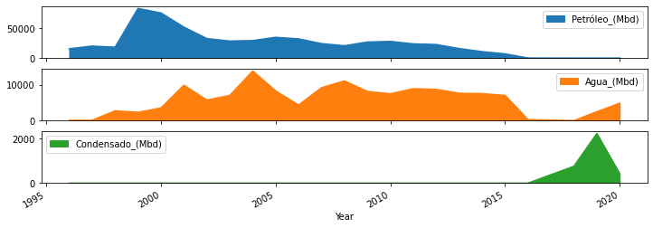

```python
#oil_chiapas=oil_tampico.drop(oil_tampico['Cuenca'])
#oil_chiapas=oil_chiapas.groupby('Fecha',axis=0).sum()
#oil_chiapas.head()
#oil_chiapas.set_index('Fecha',inplace=True)
oil_chiapas['Petróleo_(Mbd)']=oil_chiapas['Petróleo_(Mbd)']*1000
oil_chiapas['Agua_(Mbd)']=oil_chiapas['Agua_(Mbd)']*1000
oil_chiapas['Condensado_(Mbd)']=oil_chiapas['Condensado_(Mbd)']*1000

oil_chiapas.plot.area(figsize=(12, 4), subplots=True)
```

[output not shown]

[figure not shown]

```python
#oil_sabinas=oil_sabinas.groupby('Fecha',axis=0).sum()

oil_sabinas.set_index('Fecha',inplace=True)
oil_sabinas['Petróleo_(Mbd)']=oil_sabinas['Petróleo_(Mbd)']*1000

oil_sabinas['Petróleo_(Mbd)'].plot.area(figsize=(12, 4), subplots=True)
```